# Proyecto Analisis de Datos - Limpieza

### Modelo de *Forecast* de demanda para el uso de máquinas de entretenimiento en un casino de Chile

**Integrantes:**

- Adolfo Fuentes Jofré
- Juan Francisco Calderon

## Introducción

### Problema o necesidad

Las operaciones y la planificación de demanda de un Casino responden a factores que son conocidos pero también a factores altamente variables dependiendo de la estacionalidad de la temporada del año, día de la semana y horario del día. La toma de decisiones en temas de logística, adquisiciones, operaciones de RRHH y otros aspectos deben estar basadas en datos y predicciones deben considerar el historial de la demanda y el comportamiento estacional de los usuarios el cual es variable en el tiempo. Se utilizará un dataset de máquinas tragamonedas en un casino en Chile durante todo lo que va del año 2022, identificaremos patrones de uso y trataremos de implementar predicciones respecto al uso futuro de las máquinas en este casino.

### Dataset

Base de Datos Interna de la compañía que registra la cantidad de máquinas en uso en un momento especifico del día. La BBDD tiene 347.863 registros.

### Repositorio

https://github.com/adolfofuentesjofre/capston_project_analisis_de_datos

## Analisis Exploratorio

```python
import pandas as pd
import numpy as np
import matplotlib.pyplot as plt
import researchpy as rp
import scipy.stats as stats
from scipy.stats import f_oneway
import seaborn
from datetime import datetime, timedelta
import matplotlib.dates as mdates
from Funciones.Funciones_feriados_semana import Feriado, Diaantesdeferiado, semana_del_mes
```

### BBDD a estudiar

Se importa la BBDD de "CENSO" utilizada por la Compañía para monitorear la cantidad de máquinas utilizadas en cada una de las unidades (locales estudiados). Estos registros corresponden a una foto que se captura cada 30 minutos. Esta BBDD tiene 347.863 registros y está desagregada por categoría de cliente (Columna "Categoria"), que representa una segmentación de valor interna de la Compañía.

```python
df=pd.read_csv('C:/Users/adolf/Desktop/Python/UDD/analisis/proyecto/Data/raw/Censo.csv', sep=';')
df
```

|  | casino_id | Jornada | Fecha_Censo | Hora | Minutos | Categoria | Dia | Semana | Año | Mes | Sesiones |
| --- | --- | --- | --- | --- | --- | --- | --- | --- | --- | --- | --- |
| 0 | 9 | 2022-03-16 | 2022-03-17 02:30:00.913 | 2 | 30 | Silver | 3 | 12 | 2022 | 3 | 1 |
| 1 | 11 | 2022-03-28 | 2022-03-28 21:00:01.883 | 21 | 0 | NaN | 1 | 14 | 2022 | 3 | 14 |
| 2 | 7 | 2022-02-07 | 2022-02-08 00:00:00.720 | 0 | 0 | Seven Stars | 1 | 7 | 2022 | 2 | 1 |
| 3 | 1 | 2022-01-28 | 2022-01-28 20:00:01.960 | 20 | 0 | Gold | 5 | 5 | 2022 | 1 | 28 |
| 4 | 7 | 2022-08-20 | 2022-08-20 13:30:00.870 | 13 | 30 | Silver | 6 | 34 | 2022 | 8 | 1 |
| ... | ... | ... | ... | ... | ... | ... | ... | ... | ... | ... | ... |
| 347858 | 9 | 2022-03-16 | 2022-03-16 17:00:01.143 | 17 | 0 | Silver | 3 | 12 | 2022 | 3 | 5 |
| 347859 | 10 | 2022-04-29 | 2022-04-29 14:30:00.447 | 14 | 30 | Gold | 5 | 18 | 2022 | 4 | 13 |
| 347860 | 10 | 2022-03-27 | 2022-03-28 02:00:00.467 | 2 | 0 | Diamond | 7 | 13 | 2022 | 3 | 9 |
| 347861 | 1 | 2022-04-09 | 2022-04-09 19:00:00.487 | 19 | 0 | Seven Stars | 6 | 15 | 2022 | 4 | 3 |
| 347862 | 6 | 2022-02-16 | 2022-02-16 21:30:00.813 | 21 | 30 | Platinum | 3 | 8 | 2022 | 2 | 47 |

347863 rows × 11 columns

**Filtraremos solo datos del año 2022**

```python
df=df[df['Año']==2022]
df
```

|  | casino_id | Jornada | Fecha_Censo | Hora | Minutos | Categoria | Dia | Semana | Año | Mes | Sesiones |
| --- | --- | --- | --- | --- | --- | --- | --- | --- | --- | --- | --- |
| 0 | 9 | 2022-03-16 | 2022-03-17 02:30:00.913 | 2 | 30 | Silver | 3 | 12 | 2022 | 3 | 1 |
| 1 | 11 | 2022-03-28 | 2022-03-28 21:00:01.883 | 21 | 0 | NaN | 1 | 14 | 2022 | 3 | 14 |
| 2 | 7 | 2022-02-07 | 2022-02-08 00:00:00.720 | 0 | 0 | Seven Stars | 1 | 7 | 2022 | 2 | 1 |
| 3 | 1 | 2022-01-28 | 2022-01-28 20:00:01.960 | 20 | 0 | Gold | 5 | 5 | 2022 | 1 | 28 |
| 4 | 7 | 2022-08-20 | 2022-08-20 13:30:00.870 | 13 | 30 | Silver | 6 | 34 | 2022 | 8 | 1 |
| ... | ... | ... | ... | ... | ... | ... | ... | ... | ... | ... | ... |
| 347858 | 9 | 2022-03-16 | 2022-03-16 17:00:01.143 | 17 | 0 | Silver | 3 | 12 | 2022 | 3 | 5 |
| 347859 | 10 | 2022-04-29 | 2022-04-29 14:30:00.447 | 14 | 30 | Gold | 5 | 18 | 2022 | 4 | 13 |
| 347860 | 10 | 2022-03-27 | 2022-03-28 02:00:00.467 | 2 | 0 | Diamond | 7 | 13 | 2022 | 3 | 9 |
| 347861 | 1 | 2022-04-09 | 2022-04-09 19:00:00.487 | 19 | 0 | Seven Stars | 6 | 15 | 2022 | 4 | 3 |
| 347862 | 6 | 2022-02-16 | 2022-02-16 21:30:00.813 | 21 | 30 | Platinum | 3 | 8 | 2022 | 2 | 47 |

347449 rows × 11 columns

**Veremos que unidad (local) presenta una mayor cantidad de registros por completitud de datos, de modo de elegir un local con la mayor granularidad posible de datos**

```python
df.groupby(['casino_id'])['casino_id'].count()
```

```
casino_id
1     46471
3     44346
4     34032
6     40849
7     48625
8     20302
9     38500
10    48077
11    26247
Name: casino_id, dtype: int64
```

**Se filtra para la unidad/local # 7 debido a que es la que presenta mayor cantidad de registros**

```python
df_filtro=df[df['casino_id']==7]
df_filtro
```

|  | casino_id | Jornada | Fecha_Censo | Hora | Minutos | Categoria | Dia | Semana | Año | Mes | Sesiones |
| --- | --- | --- | --- | --- | --- | --- | --- | --- | --- | --- | --- |
| 2 | 7 | 2022-02-07 | 2022-02-08 00:00:00.720 | 0 | 0 | Seven Stars | 1 | 7 | 2022 | 2 | 1 |
| 4 | 7 | 2022-08-20 | 2022-08-20 13:30:00.870 | 13 | 30 | Silver | 6 | 34 | 2022 | 8 | 1 |
| 5 | 7 | 2022-02-14 | 2022-02-14 17:00:00.263 | 17 | 0 | Diamond | 1 | 8 | 2022 | 2 | 8 |
| 29 | 7 | 2022-06-02 | 2022-06-02 11:30:00.260 | 11 | 30 | Gold | 4 | 23 | 2022 | 6 | 1 |
| 49 | 7 | 2022-06-15 | 2022-06-16 00:00:00.230 | 0 | 0 | Platinum | 3 | 25 | 2022 | 6 | 16 |
| ... | ... | ... | ... | ... | ... | ... | ... | ... | ... | ... | ... |
| 347814 | 7 | 2022-09-10 | 2022-09-11 03:30:01.003 | 3 | 30 | Platinum | 6 | 37 | 2022 | 9 | 14 |
| 347829 | 7 | 2022-02-01 | 2022-02-01 13:30:00.650 | 13 | 30 | Gold | 2 | 6 | 2022 | 2 | 2 |
| 347835 | 7 | 2022-05-26 | 2022-05-26 18:00:00.267 | 18 | 0 | Diamond | 4 | 22 | 2022 | 5 | 15 |
| 347841 | 7 | 2022-07-17 | 2022-07-17 15:30:00.357 | 15 | 30 | Platinum | 7 | 29 | 2022 | 7 | 4 |
| 347852 | 7 | 2022-07-23 | 2022-07-23 22:30:00.500 | 22 | 30 | Diamond | 6 | 30 | 2022 | 7 | 26 |

48625 rows × 11 columns

### Prueba de Concepto

**Para poder explorar de mejor manera el dataset se filtra dos dias, el 28 y 29 de enero que corresponde a dias viernes y sabado**

Nuestra creencia *a priori* basada en la observación **sin acceso a datos** es que el consumo en los locales de la Compañía sea significativamente mayor durante los fines de semana y en horario nocturno. Así, esta primera prueba de concepto consiste en analizar numérica y visualmente un set de datos extraído del set total y que corresponde a la fecha señalada.

```python
df_filtro_dia=df_filtro[(df_filtro['Jornada']=='2022-01-28')|(df_filtro['Jornada']=='2022-01-29')]
df_filtro_dia.head()
```

|  | casino_id | Jornada | Fecha_Censo | Hora | Minutos | Categoria | Dia | Semana | Año | Mes | Sesiones |
| --- | --- | --- | --- | --- | --- | --- | --- | --- | --- | --- | --- |
| 1327 | 7 | 2022-01-29 | 2022-01-30 02:30:00.967 | 2 | 30 | NaN | 6 | 5 | 2022 | 1 | 147 |
| 2732 | 7 | 2022-01-29 | 2022-01-29 12:30:00.357 | 12 | 30 | Diamond | 6 | 5 | 2022 | 1 | 7 |
| 3103 | 7 | 2022-01-29 | 2022-01-29 20:30:00.227 | 20 | 30 | Silver | 6 | 5 | 2022 | 1 | 16 |
| 3419 | 7 | 2022-01-29 | 2022-01-29 15:00:00.717 | 15 | 0 | Seven Stars | 6 | 5 | 2022 | 1 | 1 |
| 5024 | 7 | 2022-01-28 | 2022-01-28 18:30:00.017 | 18 | 30 | Silver | 5 | 5 | 2022 | 1 | 4 |

**Se agruparán los datos para ver cuantos registros existen por tramo horario**

Nuestra creencia es que habrá mayor consumo durante los horarios vespertinos y nocturnos que corresponden a la hora en la que la gente sale a "divertirse".

```python
df_group=df_filtro_dia.groupby(["Hora"]).count()
```

```python
df_group.head()
df_group
```

| Hora | casino_id | Jornada | Fecha_Censo | Minutos | Categoria | Dia | Semana | Año | Mes | Sesiones |
| --- | --- | --- | --- | --- | --- | --- | --- | --- | --- | --- |
| 0 | 24 | 24 | 24 | 24 | 20 | 24 | 24 | 24 | 24 | 24 |
| 1 | 24 | 24 | 24 | 24 | 20 | 24 | 24 | 24 | 24 | 24 |
| 2 | 24 | 24 | 24 | 24 | 20 | 24 | 24 | 24 | 24 | 24 |
| 3 | 24 | 24 | 24 | 24 | 20 | 24 | 24 | 24 | 24 | 24 |
| 4 | 24 | 24 | 24 | 24 | 20 | 24 | 24 | 24 | 24 | 24 |
| 5 | 24 | 24 | 24 | 24 | 20 | 24 | 24 | 24 | 24 | 24 |
| 6 | 21 | 21 | 21 | 21 | 17 | 21 | 21 | 21 | 21 | 21 |
| 7 | 8 | 8 | 8 | 8 | 4 | 8 | 8 | 8 | 8 | 8 |
| 8 | 4 | 4 | 4 | 4 | 0 | 4 | 4 | 4 | 4 | 4 |
| 9 | 4 | 4 | 4 | 4 | 0 | 4 | 4 | 4 | 4 | 4 |
| 10 | 5 | 5 | 5 | 5 | 1 | 5 | 5 | 5 | 5 | 5 |
| 11 | 16 | 16 | 16 | 16 | 12 | 16 | 16 | 16 | 16 | 16 |
| 12 | 18 | 18 | 18 | 18 | 14 | 18 | 18 | 18 | 18 | 18 |
| 13 | 22 | 22 | 22 | 22 | 18 | 22 | 22 | 22 | 22 | 22 |
| 14 | 21 | 21 | 21 | 21 | 17 | 21 | 21 | 21 | 21 | 21 |
| 15 | 22 | 22 | 22 | 22 | 18 | 22 | 22 | 22 | 22 | 22 |
| 16 | 18 | 18 | 18 | 18 | 15 | 18 | 18 | 18 | 18 | 18 |
| 17 | 24 | 24 | 24 | 24 | 20 | 24 | 24 | 24 | 24 | 24 |
| 18 | 18 | 18 | 18 | 18 | 15 | 18 | 18 | 18 | 18 | 18 |
| 19 | 24 | 24 | 24 | 24 | 20 | 24 | 24 | 24 | 24 | 24 |
| 20 | 24 | 24 | 24 | 24 | 20 | 24 | 24 | 24 | 24 | 24 |
| 21 | 18 | 18 | 18 | 18 | 15 | 18 | 18 | 18 | 18 | 18 |
| 22 | 18 | 18 | 18 | 18 | 15 | 18 | 18 | 18 | 18 | 18 |
| 23 | 24 | 24 | 24 | 24 | 20 | 24 | 24 | 24 | 24 | 24 |

### Unidad de análisis

```python
df_group2=df_filtro_dia.groupby(['Hora','Dia','Semana','Jornada','Mes'])['Sesiones'].sum().reset_index()
df_group2.sort_values(by=['Jornada','Hora']).reset_index(drop=True)
df_group2.head()
```

|  | Hora | Dia | Semana | Jornada | Mes | Sesiones |
| --- | --- | --- | --- | --- | --- | --- |
| 0 | 0 | 5 | 5 | 2022-01-28 | 1 | 557 |
| 1 | 0 | 6 | 5 | 2022-01-29 | 1 | 632 |
| 2 | 1 | 5 | 5 | 2022-01-28 | 1 | 504 |
| 3 | 1 | 6 | 5 | 2022-01-29 | 1 | 586 |
| 4 | 2 | 5 | 5 | 2022-01-28 | 1 | 433 |

**Creamos las variables time, date y datetime (Timestamp) las que serán utilizadas posteriormente**

```python
df_group2['time'] = df_group2['Hora'].astype(str)+':00:00'
```

```python
df_group2['date'] = pd.to_datetime(df_group2['Jornada']).dt.date.astype(str)
```

```python
df_group2['datetime'] = pd.to_datetime(df_group2['Jornada'] + ' ' + df_group2['time'])
```

```python
df_group2_order=df_group2.sort_values(by=['datetime']).reset_index(drop=True)
df_group2_order
```

|  | Hora | Dia | Semana | Jornada | Mes | Sesiones | time | date | datetime |
| --- | --- | --- | --- | --- | --- | --- | --- | --- | --- |
| 0 | 0 | 5 | 5 | 2022-01-28 | 1 | 557 | 0:00:00 | 2022-01-28 | 2022-01-28 00:00:00 |
| 1 | 1 | 5 | 5 | 2022-01-28 | 1 | 504 | 1:00:00 | 2022-01-28 | 2022-01-28 01:00:00 |
| 2 | 2 | 5 | 5 | 2022-01-28 | 1 | 433 | 2:00:00 | 2022-01-28 | 2022-01-28 02:00:00 |
| 3 | 3 | 5 | 5 | 2022-01-28 | 1 | 330 | 3:00:00 | 2022-01-28 | 2022-01-28 03:00:00 |
| 4 | 4 | 5 | 5 | 2022-01-28 | 1 | 250 | 4:00:00 | 2022-01-28 | 2022-01-28 04:00:00 |
| 5 | 5 | 5 | 5 | 2022-01-28 | 1 | 141 | 5:00:00 | 2022-01-28 | 2022-01-28 05:00:00 |
| 6 | 6 | 5 | 5 | 2022-01-28 | 1 | 85 | 6:00:00 | 2022-01-28 | 2022-01-28 06:00:00 |
| 7 | 7 | 5 | 5 | 2022-01-28 | 1 | 4 | 7:00:00 | 2022-01-28 | 2022-01-28 07:00:00 |
| 8 | 8 | 5 | 5 | 2022-01-28 | 1 | 3 | 8:00:00 | 2022-01-28 | 2022-01-28 08:00:00 |
| 9 | 9 | 5 | 5 | 2022-01-28 | 1 | 3 | 9:00:00 | 2022-01-28 | 2022-01-28 09:00:00 |
| 10 | 10 | 5 | 5 | 2022-01-28 | 1 | 2 | 10:00:00 | 2022-01-28 | 2022-01-28 10:00:00 |
| 11 | 11 | 5 | 5 | 2022-01-28 | 1 | 11 | 11:00:00 | 2022-01-28 | 2022-01-28 11:00:00 |
| 12 | 12 | 5 | 5 | 2022-01-28 | 1 | 30 | 12:00:00 | 2022-01-28 | 2022-01-28 12:00:00 |
| 13 | 13 | 5 | 5 | 2022-01-28 | 1 | 54 | 13:00:00 | 2022-01-28 | 2022-01-28 13:00:00 |
| 14 | 14 | 5 | 5 | 2022-01-28 | 1 | 53 | 14:00:00 | 2022-01-28 | 2022-01-28 14:00:00 |
| 15 | 15 | 5 | 5 | 2022-01-28 | 1 | 59 | 15:00:00 | 2022-01-28 | 2022-01-28 15:00:00 |
| 16 | 16 | 5 | 5 | 2022-01-28 | 1 | 86 | 16:00:00 | 2022-01-28 | 2022-01-28 16:00:00 |
| 17 | 17 | 5 | 5 | 2022-01-28 | 1 | 125 | 17:00:00 | 2022-01-28 | 2022-01-28 17:00:00 |
| 18 | 18 | 5 | 5 | 2022-01-28 | 1 | 174 | 18:00:00 | 2022-01-28 | 2022-01-28 18:00:00 |
| 19 | 19 | 5 | 5 | 2022-01-28 | 1 | 190 | 19:00:00 | 2022-01-28 | 2022-01-28 19:00:00 |
| 20 | 20 | 5 | 5 | 2022-01-28 | 1 | 266 | 20:00:00 | 2022-01-28 | 2022-01-28 20:00:00 |
| 21 | 21 | 5 | 5 | 2022-01-28 | 1 | 188 | 21:00:00 | 2022-01-28 | 2022-01-28 21:00:00 |
| 22 | 22 | 5 | 5 | 2022-01-28 | 1 | 278 | 22:00:00 | 2022-01-28 | 2022-01-28 22:00:00 |
| 23 | 23 | 5 | 5 | 2022-01-28 | 1 | 563 | 23:00:00 | 2022-01-28 | 2022-01-28 23:00:00 |
| 24 | 0 | 6 | 5 | 2022-01-29 | 1 | 632 | 0:00:00 | 2022-01-29 | 2022-01-29 00:00:00 |
| 25 | 1 | 6 | 5 | 2022-01-29 | 1 | 586 | 1:00:00 | 2022-01-29 | 2022-01-29 01:00:00 |
| 26 | 2 | 6 | 5 | 2022-01-29 | 1 | 438 | 2:00:00 | 2022-01-29 | 2022-01-29 02:00:00 |
| 27 | 3 | 6 | 5 | 2022-01-29 | 1 | 360 | 3:00:00 | 2022-01-29 | 2022-01-29 03:00:00 |
| 28 | 4 | 6 | 5 | 2022-01-29 | 1 | 205 | 4:00:00 | 2022-01-29 | 2022-01-29 04:00:00 |
| 29 | 5 | 6 | 5 | 2022-01-29 | 1 | 144 | 5:00:00 | 2022-01-29 | 2022-01-29 05:00:00 |
| 30 | 6 | 6 | 5 | 2022-01-29 | 1 | 72 | 6:00:00 | 2022-01-29 | 2022-01-29 06:00:00 |
| 31 | 7 | 6 | 5 | 2022-01-29 | 1 | 17 | 7:00:00 | 2022-01-29 | 2022-01-29 07:00:00 |
| 32 | 8 | 6 | 5 | 2022-01-29 | 1 | 8 | 8:00:00 | 2022-01-29 | 2022-01-29 08:00:00 |
| 33 | 9 | 6 | 5 | 2022-01-29 | 1 | 10 | 9:00:00 | 2022-01-29 | 2022-01-29 09:00:00 |
| 34 | 10 | 6 | 5 | 2022-01-29 | 1 | 14 | 10:00:00 | 2022-01-29 | 2022-01-29 10:00:00 |
| 35 | 11 | 6 | 5 | 2022-01-29 | 1 | 26 | 11:00:00 | 2022-01-29 | 2022-01-29 11:00:00 |
| 36 | 12 | 6 | 5 | 2022-01-29 | 1 | 47 | 12:00:00 | 2022-01-29 | 2022-01-29 12:00:00 |
| 37 | 13 | 6 | 5 | 2022-01-29 | 1 | 73 | 13:00:00 | 2022-01-29 | 2022-01-29 13:00:00 |
| 38 | 14 | 6 | 5 | 2022-01-29 | 1 | 103 | 14:00:00 | 2022-01-29 | 2022-01-29 14:00:00 |
| 39 | 15 | 6 | 5 | 2022-01-29 | 1 | 94 | 15:00:00 | 2022-01-29 | 2022-01-29 15:00:00 |
| 40 | 16 | 6 | 5 | 2022-01-29 | 1 | 72 | 16:00:00 | 2022-01-29 | 2022-01-29 16:00:00 |
| 41 | 17 | 6 | 5 | 2022-01-29 | 1 | 227 | 17:00:00 | 2022-01-29 | 2022-01-29 17:00:00 |
| 42 | 18 | 6 | 5 | 2022-01-29 | 1 | 155 | 18:00:00 | 2022-01-29 | 2022-01-29 18:00:00 |
| 43 | 19 | 6 | 5 | 2022-01-29 | 1 | 369 | 19:00:00 | 2022-01-29 | 2022-01-29 19:00:00 |
| 44 | 20 | 6 | 5 | 2022-01-29 | 1 | 381 | 20:00:00 | 2022-01-29 | 2022-01-29 20:00:00 |
| 45 | 21 | 6 | 5 | 2022-01-29 | 1 | 440 | 21:00:00 | 2022-01-29 | 2022-01-29 21:00:00 |
| 46 | 22 | 6 | 5 | 2022-01-29 | 1 | 501 | 22:00:00 | 2022-01-29 | 2022-01-29 22:00:00 |
| 47 | 23 | 6 | 5 | 2022-01-29 | 1 | 675 | 23:00:00 | 2022-01-29 | 2022-01-29 23:00:00 |

**Verificaremos el tipo de dato para verificar que el timestamp este bien construido**

```python
df_group2_order.dtypes
```

```
Hora                 int64
Dia                  int64
Semana               int64
Jornada             object
Mes                  int64
Sesiones             int64
time                object
date                object
datetime    datetime64[ns]
dtype: object
```

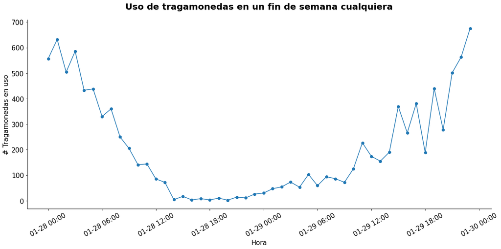

```python
def hide_border(ax):
    ax.spines['bottom'].set_visible(True)
    ax.spines['left'].set_visible(True)
    ax.spines['right'].set_visible(False)
    ax.spines['top'].set_visible(False)

fig, ax = plt.subplots(1,1, figsize=(16,8))
ax.plot(df_group2_order['datetime'], df_group2['Sesiones'], 'o-')
ax.set_xlabel("Hora",fontsize=15)
ax.set_ylabel("# Tragamonedas en uso",fontsize=15)
ax.xaxis.set_major_formatter(mdates.DateFormatter("%m-%d %H:%M"))
plt.setp(ax.get_xticklabels(), rotation = 30,fontsize=15)
plt.yticks(fontsize=15)
ax.set_title("Uso de tragamonedas en un fin de semana cualquiera",pad=24,fontweight=700,fontsize=20)
hide_border(ax)
fig.tight_layout()
```

### Analisis Totalidad de los datos

**Replicaremos el mismo preprocesamiento que se utilizó para 2 dias, pero ahora para la totalidad de los registros del casino 7**

```python
df_group3=df_filtro.groupby(['Hora','Dia','Semana','Jornada','Mes'])['Sesiones'].sum().reset_index()
```

```python
df_group3.sort_values(by=['Jornada','Hora']).reset_index(drop=True)
```

|  | Hora | Dia | Semana | Jornada | Mes | Sesiones |
| --- | --- | --- | --- | --- | --- | --- |
| 0 | 0 | 6 | 1 | 2022-01-01 | 1 | 620 |
| 1 | 1 | 6 | 1 | 2022-01-01 | 1 | 566 |
| 2 | 2 | 6 | 1 | 2022-01-01 | 1 | 472 |
| 3 | 3 | 6 | 1 | 2022-01-01 | 1 | 369 |
| 4 | 4 | 6 | 1 | 2022-01-01 | 1 | 247 |
| ... | ... | ... | ... | ... | ... | ... |
| 5359 | 19 | 1 | 38 | 2022-09-12 | 9 | 56 |
| 5360 | 20 | 1 | 38 | 2022-09-12 | 9 | 108 |
| 5361 | 21 | 1 | 38 | 2022-09-12 | 9 | 126 |
| 5362 | 22 | 1 | 38 | 2022-09-12 | 9 | 169 |
| 5363 | 23 | 1 | 38 | 2022-09-12 | 9 | 160 |

5364 rows × 6 columns

**De esta manera tenemos una serie de tiempo con 5364 registros que corresponde todos los datos desde inicio del 2022**

```python
df_group3['time'] = df_group3['Hora'].astype(str)+':00:00'
```

```python
df_group3['date'] = pd.to_datetime(df_group3['Jornada']).dt.date.astype(str)
```

```python
df_group3['datetime'] = pd.to_datetime(df_group3['Jornada'] + ' ' + df_group3['time'])
```

### Unidad de análisis totalidad de registros

```python
df_group3_order=df_group3.sort_values(by=['datetime']).reset_index(drop=True)
df_group3_order.head(26)
```

|  | Hora | Dia | Semana | Jornada | Mes | Sesiones | time | date | datetime |
| --- | --- | --- | --- | --- | --- | --- | --- | --- | --- |
| 0 | 0 | 6 | 1 | 2022-01-01 | 1 | 620 | 0:00:00 | 2022-01-01 | 2022-01-01 00:00:00 |
| 1 | 1 | 6 | 1 | 2022-01-01 | 1 | 566 | 1:00:00 | 2022-01-01 | 2022-01-01 01:00:00 |
| 2 | 2 | 6 | 1 | 2022-01-01 | 1 | 472 | 2:00:00 | 2022-01-01 | 2022-01-01 02:00:00 |
| 3 | 3 | 6 | 1 | 2022-01-01 | 1 | 369 | 3:00:00 | 2022-01-01 | 2022-01-01 03:00:00 |
| 4 | 4 | 6 | 1 | 2022-01-01 | 1 | 247 | 4:00:00 | 2022-01-01 | 2022-01-01 04:00:00 |
| 5 | 5 | 6 | 1 | 2022-01-01 | 1 | 140 | 5:00:00 | 2022-01-01 | 2022-01-01 05:00:00 |
| 6 | 6 | 6 | 1 | 2022-01-01 | 1 | 62 | 6:00:00 | 2022-01-01 | 2022-01-01 06:00:00 |
| 7 | 7 | 6 | 1 | 2022-01-01 | 1 | 18 | 7:00:00 | 2022-01-01 | 2022-01-01 07:00:00 |
| 8 | 8 | 6 | 1 | 2022-01-01 | 1 | 2 | 8:00:00 | 2022-01-01 | 2022-01-01 08:00:00 |
| 9 | 9 | 6 | 1 | 2022-01-01 | 1 | 3 | 9:00:00 | 2022-01-01 | 2022-01-01 09:00:00 |
| 10 | 10 | 6 | 1 | 2022-01-01 | 1 | 2 | 10:00:00 | 2022-01-01 | 2022-01-01 10:00:00 |
| 11 | 11 | 6 | 1 | 2022-01-01 | 1 | 4 | 11:00:00 | 2022-01-01 | 2022-01-01 11:00:00 |
| 12 | 12 | 6 | 1 | 2022-01-01 | 1 | 14 | 12:00:00 | 2022-01-01 | 2022-01-01 12:00:00 |
| 13 | 13 | 6 | 1 | 2022-01-01 | 1 | 67 | 13:00:00 | 2022-01-01 | 2022-01-01 13:00:00 |
| 14 | 14 | 6 | 1 | 2022-01-01 | 1 | 55 | 14:00:00 | 2022-01-01 | 2022-01-01 14:00:00 |
| 15 | 15 | 6 | 1 | 2022-01-01 | 1 | 115 | 15:00:00 | 2022-01-01 | 2022-01-01 15:00:00 |
| 16 | 16 | 6 | 1 | 2022-01-01 | 1 | 233 | 16:00:00 | 2022-01-01 | 2022-01-01 16:00:00 |
| 17 | 17 | 6 | 1 | 2022-01-01 | 1 | 290 | 17:00:00 | 2022-01-01 | 2022-01-01 17:00:00 |
| 18 | 18 | 6 | 1 | 2022-01-01 | 1 | 341 | 18:00:00 | 2022-01-01 | 2022-01-01 18:00:00 |
| 19 | 19 | 6 | 1 | 2022-01-01 | 1 | 339 | 19:00:00 | 2022-01-01 | 2022-01-01 19:00:00 |
| 20 | 20 | 6 | 1 | 2022-01-01 | 1 | 387 | 20:00:00 | 2022-01-01 | 2022-01-01 20:00:00 |
| 21 | 21 | 6 | 1 | 2022-01-01 | 1 | 445 | 21:00:00 | 2022-01-01 | 2022-01-01 21:00:00 |
| 22 | 22 | 6 | 1 | 2022-01-01 | 1 | 511 | 22:00:00 | 2022-01-01 | 2022-01-01 22:00:00 |
| 23 | 23 | 6 | 1 | 2022-01-01 | 1 | 549 | 23:00:00 | 2022-01-01 | 2022-01-01 23:00:00 |
| 24 | 0 | 7 | 1 | 2022-01-02 | 1 | 307 | 0:00:00 | 2022-01-02 | 2022-01-02 00:00:00 |
| 25 | 1 | 7 | 1 | 2022-01-02 | 1 | 233 | 1:00:00 | 2022-01-02 | 2022-01-02 01:00:00 |

```python
df_group3_order
```

|  | Hora | Dia | Semana | Jornada | Mes | Sesiones | time | date | datetime |
| --- | --- | --- | --- | --- | --- | --- | --- | --- | --- |
| 0 | 0 | 6 | 1 | 2022-01-01 | 1 | 620 | 0:00:00 | 2022-01-01 | 2022-01-01 00:00:00 |
| 1 | 1 | 6 | 1 | 2022-01-01 | 1 | 566 | 1:00:00 | 2022-01-01 | 2022-01-01 01:00:00 |
| 2 | 2 | 6 | 1 | 2022-01-01 | 1 | 472 | 2:00:00 | 2022-01-01 | 2022-01-01 02:00:00 |
| 3 | 3 | 6 | 1 | 2022-01-01 | 1 | 369 | 3:00:00 | 2022-01-01 | 2022-01-01 03:00:00 |
| 4 | 4 | 6 | 1 | 2022-01-01 | 1 | 247 | 4:00:00 | 2022-01-01 | 2022-01-01 04:00:00 |
| ... | ... | ... | ... | ... | ... | ... | ... | ... | ... |
| 5359 | 19 | 1 | 38 | 2022-09-12 | 9 | 56 | 19:00:00 | 2022-09-12 | 2022-09-12 19:00:00 |
| 5360 | 20 | 1 | 38 | 2022-09-12 | 9 | 108 | 20:00:00 | 2022-09-12 | 2022-09-12 20:00:00 |
| 5361 | 21 | 1 | 38 | 2022-09-12 | 9 | 126 | 21:00:00 | 2022-09-12 | 2022-09-12 21:00:00 |
| 5362 | 22 | 1 | 38 | 2022-09-12 | 9 | 169 | 22:00:00 | 2022-09-12 | 2022-09-12 22:00:00 |
| 5363 | 23 | 1 | 38 | 2022-09-12 | 9 | 160 | 23:00:00 | 2022-09-12 | 2022-09-12 23:00:00 |

5364 rows × 9 columns

### Plot de toda la Serie de Tiempo

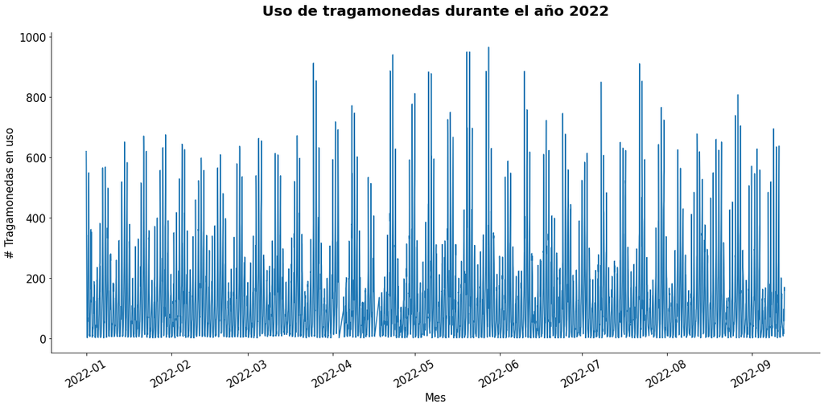

```python
def hide_border(ax):
    ax.spines['bottom'].set_visible(True)
    ax.spines['left'].set_visible(True)
    ax.spines['right'].set_visible(False)
    ax.spines['top'].set_visible(False)

fig, ax = plt.subplots(1,1, figsize=(16,8))
ax.plot(df_group3_order['datetime'], df_group3_order['Sesiones'])
ax.set_xlabel("Mes",fontsize=15)
ax.set_ylabel("# Tragamonedas en uso",fontsize=15)
plt.setp(ax.get_xticklabels(), rotation = 30,fontsize=15)
plt.yticks(fontsize=15)
ax.set_title("Uso de tragamonedas durante el año 2022",pad=24,fontweight=700,fontsize=20)
hide_border(ax)
fig.tight_layout()
```

En este gráfico, a pesar de no ser amigable visualmente, se observa que hay una periodicidad en el uso de las máquinas. En general, se observan cuatro días de "bajo uso" y tres días de "alto uso". Seguiremos explorando los datos para verificar que este patrón tiene que ver con "día de semana" versus "fin de semana".

### Plot de toda la Serie de Tiempo para el mes de Enero

```python
df_group3_order_enero=df_group3_order[df_group3_order['Mes']==1]
df_group3_order_enero.head()
```

|  | Hora | Dia | Semana | Jornada | Mes | Sesiones | time | date | datetime |
| --- | --- | --- | --- | --- | --- | --- | --- | --- | --- |
| 0 | 0 | 6 | 1 | 2022-01-01 | 1 | 620 | 0:00:00 | 2022-01-01 | 2022-01-01 00:00:00 |
| 1 | 1 | 6 | 1 | 2022-01-01 | 1 | 566 | 1:00:00 | 2022-01-01 | 2022-01-01 01:00:00 |
| 2 | 2 | 6 | 1 | 2022-01-01 | 1 | 472 | 2:00:00 | 2022-01-01 | 2022-01-01 02:00:00 |
| 3 | 3 | 6 | 1 | 2022-01-01 | 1 | 369 | 3:00:00 | 2022-01-01 | 2022-01-01 03:00:00 |
| 4 | 4 | 6 | 1 | 2022-01-01 | 1 | 247 | 4:00:00 | 2022-01-01 | 2022-01-01 04:00:00 |

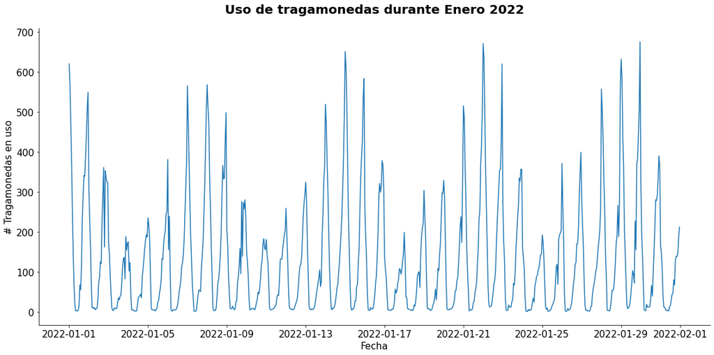

```python
def hide_border(ax):
    ax.spines['bottom'].set_visible(True)
    ax.spines['left'].set_visible(True)
    ax.spines['right'].set_visible(False)
    ax.spines['top'].set_visible(False)

fig, ax = plt.subplots(1,1, figsize=(16,8))

ax.plot(df_group3_order_enero['datetime'], df_group3_order_enero['Sesiones'])
ax.set_xlabel("Fecha",fontsize=15)
ax.set_ylabel("# Tragamonedas en uso",fontsize=15)
plt.setp(ax.get_xticklabels(),fontsize=15)
plt.yticks(fontsize=15)
ax.set_title("Uso de tragamonedas durante Enero 2022",pad=24,fontweight=700,fontsize=20)
hide_border(ax)
fig.tight_layout()
```

### Plot de uso de máquinas durante la segunda semana del mes de Enero 2022

Como vimos en el gráfico anterior existe una periodicidad en el uso de máquinas que ahora vimos a nivel mes utilizando Enero 2022 como ejemplo. Veamos si, a resolución nivel semana, podemos corroborar esta periodicidad.

```python
df_group3_order_enero_semana=df_group3_order_enero[df_group3_order_enero['Semana']==2]
```

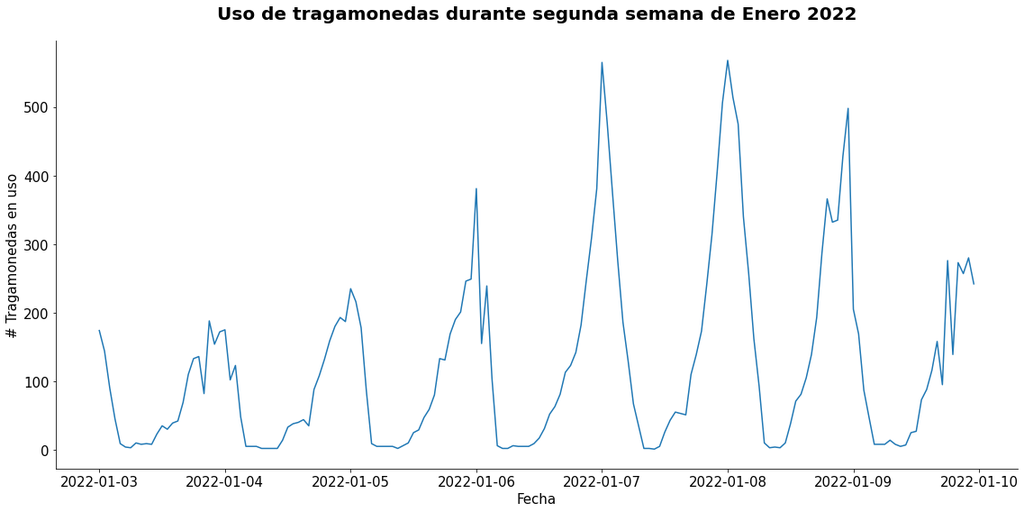

```python
def hide_border(ax):
    ax.spines['bottom'].set_visible(True)
    ax.spines['left'].set_visible(True)
    ax.spines['right'].set_visible(False)
    ax.spines['top'].set_visible(False)

fig, ax = plt.subplots(1,1, figsize=(16,8))

ax.plot(df_group3_order_enero_semana['datetime'], df_group3_order_enero_semana['Sesiones'])
ax.set_xlabel("Fecha",fontsize=15)
ax.set_ylabel("# Tragamonedas en uso",fontsize=15)
plt.setp(ax.get_xticklabels(),fontsize=15)
plt.yticks(fontsize=15)
ax.set_title("Uso de tragamonedas durante segunda semana de Enero 2022",pad=24,fontweight=700,fontsize=20)
hide_border(ax)
fig.tight_layout()
```

### Plot de Dia Promedio

```python
dia_promedio=df_group3_order.groupby(['Hora'])['Sesiones'].mean().reset_index()
dia_promedio
```

|  | Hora | Sesiones |
| --- | --- | --- |
| 0 | 0 | 336.700000 |
| 1 | 1 | 284.060000 |
| 2 | 2 | 217.530120 |
| 3 | 3 | 132.328000 |
| 4 | 4 | 74.823529 |
| 5 | 5 | 60.624242 |
| 6 | 6 | 37.163522 |
| 7 | 7 | 7.962500 |
| 8 | 8 | 7.089431 |
| 9 | 9 | 6.007143 |
| 10 | 10 | 6.666667 |
| 11 | 11 | 12.348000 |
| 12 | 12 | 27.516000 |
| 13 | 13 | 44.196000 |
| 14 | 14 | 54.152000 |
| 15 | 15 | 68.661355 |
| 16 | 16 | 113.306773 |
| 17 | 17 | 151.330677 |
| 18 | 18 | 178.312000 |
| 19 | 19 | 193.470120 |
| 20 | 20 | 226.545817 |
| 21 | 21 | 263.489960 |
| 22 | 22 | 309.665339 |
| 23 | 23 | 352.095618 |

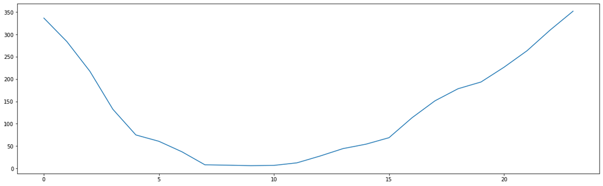

```python
plt.figure(figsize=(20, 6))
plt.plot(dia_promedio['Hora'], dia_promedio['Sesiones'])
```

El gráfico superior, la entrega por defecto de matplotlib para un gráfico de línea sobre la función "promedio" nos muestra una tendencia. Se observa que, efectivamente, el dia comienza con un alto número de máquinas en uso y que este decae al avanzar la noche y llegar la mañana, se mantiene bajo durante la mañana y la primera hora de la tarde, para después acercarse nuevamente a altos niveles de uso a medida que se acerca el horario vespertino y nocturno. Sin embargo, esta representación gráfica no entrega información acerca de la dispersión de los datos. Para eso, procedamos a realizar un *box plot*.

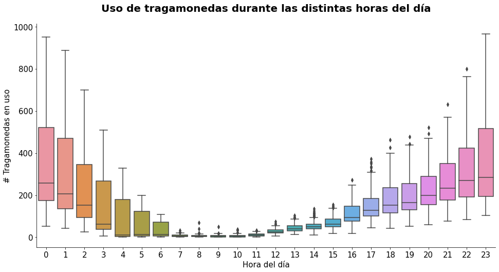

```python
def hide_border(ax):
    ax.spines['bottom'].set_visible(True)
    ax.spines['left'].set_visible(True)
    ax.spines['right'].set_visible(False)
    ax.spines['top'].set_visible(False)

fig, ax = plt.subplots(1,1, figsize=(16,8))
seaborn.boxplot(df_group3_order.Hora,df_group3_order.Sesiones,ax=ax)
ax.set_xlabel("Hora del día",fontsize=15)
ax.set_ylabel("# Tragamonedas en uso",fontsize=15)
plt.setp(ax.get_xticklabels(),fontsize=15)
plt.yticks(fontsize=15)
ax.set_title("Uso de tragamonedas durante las distintas horas del día",pad=24,fontweight=700,fontsize=20)
hide_border(ax)
```

Del gráfico superior se pueden tomar algunas conclusiones:

1. Hay horas del día en las que hay un uso masivo de máquinas en comparación con otras, lo que había sido observado en el gráfico anterior, aunque distorsionado porque ahora sabemos que la mediana y la media están distanciadas debido a la presencia de valores extremos, especialmente en las horas de alto uso.
2. Evidentemente, las primeras horas de la mañana es cuando menos uso hay y, recíprocamente, al comenzar la tarde y entrada la noche es cuando se produce el máximo de uso.
3. Esta visualización de los datos (*boxplot*) agrega valor en el sentido que aporta granularidad al análisis que se pretende hacer y las conclusiones que se puedan sacar de este análisis en un futuro.

### Plot Semana Promedio

Veamos ahora que sucede cuando vemos el promedio de uso de máquinas tragamonedas ahora a nivel de los distintos días de la semana. Para eso generemos un *dataframe* que indique promedio de sesiones (uso) para cada hora del dia, los siete dias de la semana.

```python
semana_promedio=df_group3_order.groupby(['Hora','Dia'])['Sesiones'].mean().reset_index()
semana_promedio=semana_promedio.sort_values(by=['Dia','Hora']).reset_index(drop=True)
semana_promedio
```

|  | Hora | Dia | Sesiones |
| --- | --- | --- | --- |
| 0 | 0 | 1 | 139.166667 |
| 1 | 1 | 1 | 120.416667 |
| 2 | 2 | 1 | 87.470588 |
| 3 | 3 | 1 | 39.685714 |
| 4 | 4 | 1 | 12.192308 |
| ... | ... | ... | ... |
| 163 | 19 | 7 | 250.657143 |
| 164 | 20 | 7 | 261.371429 |
| 165 | 21 | 7 | 253.742857 |
| 166 | 22 | 7 | 250.600000 |
| 167 | 23 | 7 | 242.314286 |

168 rows × 3 columns

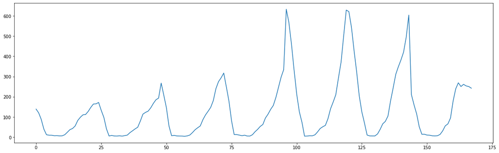

```python
plt.figure(figsize=(20, 6))
plt.plot(semana_promedio['Sesiones'])
```

Al igual que el caso anterior, este set de datos nos muestra tendencia pero, por el hecho de graficar promedios, nos esconde datos que pueden ser interesantes para investigar. Por ejemplo, cuanta dispersión hay en los distintos días de la semana. Volvamos al *df* original y grafiquemos en *boxplot* según día de la semana.

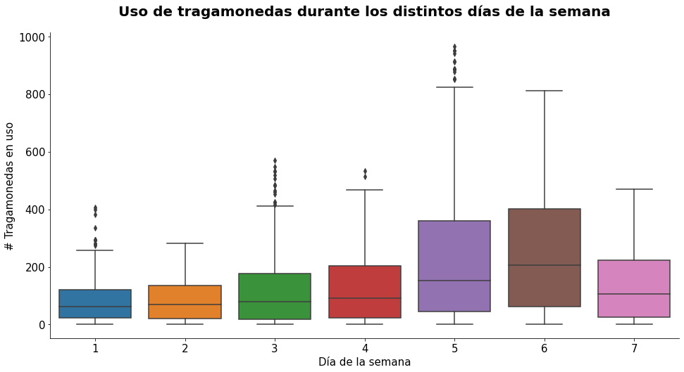

```python
def hide_border(ax):
    ax.spines['bottom'].set_visible(True)
    ax.spines['left'].set_visible(True)
    ax.spines['right'].set_visible(False)
    ax.spines['top'].set_visible(False)

fig, ax = plt.subplots(1,1, figsize=(16,8))
seaborn.boxplot(df_group3_order.Dia,df_group3_order.Sesiones,ax=ax)
ax.set_xlabel("Día de la semana",fontsize=15)
ax.set_ylabel("# Tragamonedas en uso",fontsize=15)
plt.setp(ax.get_xticklabels(),fontsize=15)
plt.yticks(fontsize=15)
ax.set_title("Uso de tragamonedas durante los distintos días de la semana",pad=24,fontweight=700,fontsize=20)
hide_border(ax)
```

### Construcción de Atributos Estacionales

**Debido a la alta estacionalidad en dias fin de semana y probablemente los dias feriados y dias previos a feriado se construirán distintos atributos**

**1) Se construirá el atributo FDS, que en rigor serán los dias Jueves, Viernes y Sabado**

```python
df_group3_order['FDS'] = np.where((df_group3_order['Dia'] == 4)|(df_group3_order['Dia'] == 5)|(df_group3_order['Dia'] == 6), 1, 0)
df_group3_order.head()
```

|  | Hora | Dia | Semana | Jornada | Mes | Sesiones | time | date | datetime | FDS |
| --- | --- | --- | --- | --- | --- | --- | --- | --- | --- | --- |
| 0 | 0 | 6 | 1 | 2022-01-01 | 1 | 620 | 0:00:00 | 2022-01-01 | 2022-01-01 00:00:00 | 1 |
| 1 | 1 | 6 | 1 | 2022-01-01 | 1 | 566 | 1:00:00 | 2022-01-01 | 2022-01-01 01:00:00 | 1 |
| 2 | 2 | 6 | 1 | 2022-01-01 | 1 | 472 | 2:00:00 | 2022-01-01 | 2022-01-01 02:00:00 | 1 |
| 3 | 3 | 6 | 1 | 2022-01-01 | 1 | 369 | 3:00:00 | 2022-01-01 | 2022-01-01 03:00:00 | 1 |
| 4 | 4 | 6 | 1 | 2022-01-01 | 1 | 247 | 4:00:00 | 2022-01-01 | 2022-01-01 04:00:00 | 1 |

```python
fds_promedio=df_group3_order.groupby(['FDS'])['Sesiones'].mean().reset_index()
fds_promedio
```

|  | FDS | Sesiones |
| --- | --- | --- |
| 0 | 0 | 100.985963 |
| 1 | 1 | 200.921585 |

```python
stats.ttest_ind(df_group3_order['Sesiones'][df_group3_order['FDS'] == 0],
                df_group3_order['Sesiones'][df_group3_order['FDS'] == 1],
                equal_var=False,alternative="less")
```

```
Ttest_indResult(statistic=-22.934095536822035, pvalue=2.6658360250515866e-108)
```

A pesar de que la tendencia es clara al comparar los promedios, quisimos aplicar un test estadístico de manera de corroborar lo esperado. Como de antemano se intuía y se visualizaba que los fines de semana se usaban mucho más intensamente las máquinas que durante la semana, utilizamos los parámetros correspondientes. En definitiva, la diferencia entre el uso de máquinas es significativa, con un *p-value* de 2.66 e-108.

**2) Se construirá el atributo feriado, que en rigor considerará el dia feriado y el dia anterior al feriado**

```python
df_group3_order['feriado'] = df_group3_order['datetime'].apply(lambda f:Feriado(f))
df_group3_order['feriado2'] = np.where((df_group3_order['feriado'] == True), 1, 0)
```

```python
df_group3_order['antesdeferiado'] = df_group3_order['datetime'].apply(lambda f: Diaantesdeferiado(f) )
df_group3_order['antesdeferiado2'] = np.where((df_group3_order['antesdeferiado'] == True),1,0)
df_group3_order['feriado_final'] = np.where((df_group3_order['antesdeferiado2'] == 1)|(df_group3_order['feriado2'] == 1),1,0)
df_group3_order.drop(['feriado', 'antesdeferiado'], axis=1)
```

|  | Hora | Dia | Semana | Jornada | Mes | Sesiones | time | date | datetime | FDS | feriado2 | antesdeferiado2 | feriado_final |
| --- | --- | --- | --- | --- | --- | --- | --- | --- | --- | --- | --- | --- | --- |
| 0 | 0 | 6 | 1 | 2022-01-01 | 1 | 620 | 0:00:00 | 2022-01-01 | 2022-01-01 00:00:00 | 1 | 1 | 0 | 1 |
| 1 | 1 | 6 | 1 | 2022-01-01 | 1 | 566 | 1:00:00 | 2022-01-01 | 2022-01-01 01:00:00 | 1 | 1 | 0 | 1 |
| 2 | 2 | 6 | 1 | 2022-01-01 | 1 | 472 | 2:00:00 | 2022-01-01 | 2022-01-01 02:00:00 | 1 | 1 | 0 | 1 |
| 3 | 3 | 6 | 1 | 2022-01-01 | 1 | 369 | 3:00:00 | 2022-01-01 | 2022-01-01 03:00:00 | 1 | 1 | 0 | 1 |
| 4 | 4 | 6 | 1 | 2022-01-01 | 1 | 247 | 4:00:00 | 2022-01-01 | 2022-01-01 04:00:00 | 1 | 1 | 0 | 1 |
| ... | ... | ... | ... | ... | ... | ... | ... | ... | ... | ... | ... | ... | ... |
| 5359 | 19 | 1 | 38 | 2022-09-12 | 9 | 56 | 19:00:00 | 2022-09-12 | 2022-09-12 19:00:00 | 0 | 0 | 0 | 0 |
| 5360 | 20 | 1 | 38 | 2022-09-12 | 9 | 108 | 20:00:00 | 2022-09-12 | 2022-09-12 20:00:00 | 0 | 0 | 0 | 0 |
| 5361 | 21 | 1 | 38 | 2022-09-12 | 9 | 126 | 21:00:00 | 2022-09-12 | 2022-09-12 21:00:00 | 0 | 0 | 0 | 0 |
| 5362 | 22 | 1 | 38 | 2022-09-12 | 9 | 169 | 22:00:00 | 2022-09-12 | 2022-09-12 22:00:00 | 0 | 0 | 0 | 0 |
| 5363 | 23 | 1 | 38 | 2022-09-12 | 9 | 160 | 23:00:00 | 2022-09-12 | 2022-09-12 23:00:00 | 0 | 0 | 0 | 0 |

5364 rows × 13 columns

```python
feriado_final_promedio=df_group3_order.groupby(['feriado_final'])['Sesiones'].mean().reset_index()
feriado_final_promedio
```

|  | feriado_final | Sesiones |
| --- | --- | --- |
| 0 | 0 | 141.091839 |
| 1 | 1 | 219.655914 |

```python
stats.ttest_ind(df_group3_order['Sesiones'][df_group3_order['feriado_final'] == 0],
                df_group3_order['Sesiones'][df_group3_order['feriado_final'] == 1],
                equal_var=False,alternative="less")
```

```
Ttest_indResult(statistic=-6.390245397040766, pvalue=3.218040126848462e-10)
```

**3) Se creará el atributo periodo del dia, el cual será una clasificación segun rango horario:**

- Madrugada
- Mañana
- Noche
- Tarde

```python
conditions=[ (df_group3_order['Hora']<=4),
             (df_group3_order['Hora']>4) & (df_group3_order['Hora']<=11),
             (df_group3_order['Hora']>11) & (df_group3_order['Hora']<=17),
             (df_group3_order['Hora']>17)
            ]
```

```python
choices=['Madrugada','Mañana','Tarde','Noche']
```

```python
df_group3_order['rango_hora'] =np.select(conditions,choices)
df_group3_order.head()
```

|  | Hora | Dia | Semana | Jornada | Mes | Sesiones | time | date | datetime | FDS | feriado | feriado2 | antesdeferiado | antesdeferiado2 | feriado_final | rango_hora |
| --- | --- | --- | --- | --- | --- | --- | --- | --- | --- | --- | --- | --- | --- | --- | --- | --- |
| 0 | 0 | 6 | 1 | 2022-01-01 | 1 | 620 | 0:00:00 | 2022-01-01 | 2022-01-01 00:00:00 | 1 | True | 1 | 0 | 0 | 1 | Madrugada |
| 1 | 1 | 6 | 1 | 2022-01-01 | 1 | 566 | 1:00:00 | 2022-01-01 | 2022-01-01 01:00:00 | 1 | True | 1 | 0 | 0 | 1 | Madrugada |
| 2 | 2 | 6 | 1 | 2022-01-01 | 1 | 472 | 2:00:00 | 2022-01-01 | 2022-01-01 02:00:00 | 1 | True | 1 | 0 | 0 | 1 | Madrugada |
| 3 | 3 | 6 | 1 | 2022-01-01 | 1 | 369 | 3:00:00 | 2022-01-01 | 2022-01-01 03:00:00 | 1 | True | 1 | 0 | 0 | 1 | Madrugada |
| 4 | 4 | 6 | 1 | 2022-01-01 | 1 | 247 | 4:00:00 | 2022-01-01 | 2022-01-01 04:00:00 | 1 | True | 1 | 0 | 0 | 1 | Madrugada |

```python
rango_hora_promedio=df_group3_order.groupby(['rango_hora'])['Sesiones'].mean().reset_index()
rango_hora_promedio
```

|  | rango_hora | Sesiones |
| --- | --- | --- |
| 0 | Madrugada | 212.272951 |
| 1 | Mañana | 20.145870 |
| 2 | Noche | 253.967399 |
| 3 | Tarde | 76.596141 |

```python
f_oneway(df_group3_order['Sesiones'][df_group3_order['rango_hora'] == "Madrugada"],
         df_group3_order['Sesiones'][df_group3_order['rango_hora'] == "Mañana"],
         df_group3_order['Sesiones'][df_group3_order['rango_hora'] == "Tarde"],
         df_group3_order['Sesiones'][df_group3_order['rango_hora'] == "Noche"])
```

```
F_onewayResult(statistic=1052.2515489623668, pvalue=0.0)
```

En este caso, llamativamente, los promedios son muy distintos para los distintos segmentos del día. Por esto, al realizar un test de ANOVA de una vía para comparar, da un *p-value* de cero, lo que se puede interpretar como que es virtualmente imposible encontrar esta distribución de datos bajo la hipótesis nula de que los promedios de grupos son iguales.

```python
df_group3_order['date'] = pd.to_datetime(df_group3_order['date'])
```

```python
df_group3_order['semana_del_mes'] = semana_del_mes(df_group3_order['date'])
```

[output not shown]

[output cut: 28139 more lines]

```python
df_group3_order
```

|  | Hora | Dia | Semana | Jornada | Mes | Sesiones | time | date | datetime | FDS | feriado | feriado2 | antesdeferiado | antesdeferiado2 | feriado_final | rango_hora | semana_del_mes |
| --- | --- | --- | --- | --- | --- | --- | --- | --- | --- | --- | --- | --- | --- | --- | --- | --- | --- |
| 0 | 0 | 6 | 1 | 2022-01-01 | 1 | 620 | 0:00:00 | 2022-01-01 | 2022-01-01 00:00:00 | 1 | True | 1 | 0 | 0 | 1 | Madrugada | Primera |
| 1 | 1 | 6 | 1 | 2022-01-01 | 1 | 566 | 1:00:00 | 2022-01-01 | 2022-01-01 01:00:00 | 1 | True | 1 | 0 | 0 | 1 | Madrugada | Primera |
| 2 | 2 | 6 | 1 | 2022-01-01 | 1 | 472 | 2:00:00 | 2022-01-01 | 2022-01-01 02:00:00 | 1 | True | 1 | 0 | 0 | 1 | Madrugada | Primera |
| 3 | 3 | 6 | 1 | 2022-01-01 | 1 | 369 | 3:00:00 | 2022-01-01 | 2022-01-01 03:00:00 | 1 | True | 1 | 0 | 0 | 1 | Madrugada | Primera |
| 4 | 4 | 6 | 1 | 2022-01-01 | 1 | 247 | 4:00:00 | 2022-01-01 | 2022-01-01 04:00:00 | 1 | True | 1 | 0 | 0 | 1 | Madrugada | Primera |
| ... | ... | ... | ... | ... | ... | ... | ... | ... | ... | ... | ... | ... | ... | ... | ... | ... | ... |
| 5359 | 19 | 1 | 38 | 2022-09-12 | 9 | 56 | 19:00:00 | 2022-09-12 | 2022-09-12 19:00:00 | 0 | False | 0 | 0 | 0 | 0 | Noche | Intermedia |
| 5360 | 20 | 1 | 38 | 2022-09-12 | 9 | 108 | 20:00:00 | 2022-09-12 | 2022-09-12 20:00:00 | 0 | False | 0 | 0 | 0 | 0 | Noche | Intermedia |
| 5361 | 21 | 1 | 38 | 2022-09-12 | 9 | 126 | 21:00:00 | 2022-09-12 | 2022-09-12 21:00:00 | 0 | False | 0 | 0 | 0 | 0 | Noche | Intermedia |
| 5362 | 22 | 1 | 38 | 2022-09-12 | 9 | 169 | 22:00:00 | 2022-09-12 | 2022-09-12 22:00:00 | 0 | False | 0 | 0 | 0 | 0 | Noche | Intermedia |
| 5363 | 23 | 1 | 38 | 2022-09-12 | 9 | 160 | 23:00:00 | 2022-09-12 | 2022-09-12 23:00:00 | 0 | False | 0 | 0 | 0 | 0 | Noche | Intermedia |

5364 rows × 17 columns

```python
semana_del_mes=df_group3_order.groupby(['semana_del_mes'])['Sesiones'].mean().reset_index()
semana_del_mes
```

|  | semana_del_mes | Sesiones |
| --- | --- | --- |
| 0 | Intermedia | 145.520159 |
| 1 | Primera | 160.462629 |
| 2 | Ultima | 121.959649 |

Interesantemente, aquí el análisis que estamos haciendo tiene que ver con la presunción de que el gasto del cliente está directamente asociado al momento en que recibe el sueldo. Generalmente en Chile esto sucede a principios de mes o bien a principios de mes y en la mitad del mes (pago "por quincena"). De todos modos, lo que está en juego aquí es verificar que el gasto en entretenimiento (asociado a máquinas tragamonedas, en este caso) es mayor en el momento más cercano a que los clientes reciban su sueldo. Verifiquemos si estas diferencias son estadísticamente significativas:

```python
f_oneway(df_group3_order['Sesiones'][df_group3_order['semana_del_mes'] == "Primera"],
         df_group3_order['Sesiones'][df_group3_order['semana_del_mes'] == "Intermedia"],
         df_group3_order['Sesiones'][df_group3_order['semana_del_mes'] == "Ultima"],
         )
```

```
F_onewayResult(statistic=10.131190203560884, pvalue=4.058579463249774e-05)
```

A pesar que los promedios son cercanos, un test de ANOVA de una vía indica que hay diferencias significativas en el uso de máquinas tragamonedas en las distintas semanas del mes, lo que *a priori* corrobora la hipótesis planteada, con un *p-value* de 4,06e-05.

```python
df_group3_order=df_group3_order[df_group3_order['datetime']<'2022-09-11']
df_group3_order
```

|  | Hora | Dia | Semana | Jornada | Mes | Sesiones | time | date | datetime | FDS | feriado | feriado2 | antesdeferiado | antesdeferiado2 | feriado_final | rango_hora | semana_del_mes |
| --- | --- | --- | --- | --- | --- | --- | --- | --- | --- | --- | --- | --- | --- | --- | --- | --- | --- |
| 0 | 0 | 6 | 1 | 2022-01-01 | 1 | 620 | 0:00:00 | 2022-01-01 | 2022-01-01 00:00:00 | 1 | True | 1 | 0 | 0 | 1 | Madrugada | Primera |
| 1 | 1 | 6 | 1 | 2022-01-01 | 1 | 566 | 1:00:00 | 2022-01-01 | 2022-01-01 01:00:00 | 1 | True | 1 | 0 | 0 | 1 | Madrugada | Primera |
| 2 | 2 | 6 | 1 | 2022-01-01 | 1 | 472 | 2:00:00 | 2022-01-01 | 2022-01-01 02:00:00 | 1 | True | 1 | 0 | 0 | 1 | Madrugada | Primera |
| 3 | 3 | 6 | 1 | 2022-01-01 | 1 | 369 | 3:00:00 | 2022-01-01 | 2022-01-01 03:00:00 | 1 | True | 1 | 0 | 0 | 1 | Madrugada | Primera |
| 4 | 4 | 6 | 1 | 2022-01-01 | 1 | 247 | 4:00:00 | 2022-01-01 | 2022-01-01 04:00:00 | 1 | True | 1 | 0 | 0 | 1 | Madrugada | Primera |
| ... | ... | ... | ... | ... | ... | ... | ... | ... | ... | ... | ... | ... | ... | ... | ... | ... | ... |
| 5326 | 19 | 6 | 37 | 2022-09-10 | 9 | 307 | 19:00:00 | 2022-09-10 | 2022-09-10 19:00:00 | 1 | False | 0 | 0 | 0 | 0 | Noche | Intermedia |
| 5327 | 20 | 6 | 37 | 2022-09-10 | 9 | 399 | 20:00:00 | 2022-09-10 | 2022-09-10 20:00:00 | 1 | False | 0 | 0 | 0 | 0 | Noche | Intermedia |
| 5328 | 21 | 6 | 37 | 2022-09-10 | 9 | 460 | 21:00:00 | 2022-09-10 | 2022-09-10 21:00:00 | 1 | False | 0 | 0 | 0 | 0 | Noche | Intermedia |
| 5329 | 22 | 6 | 37 | 2022-09-10 | 9 | 561 | 22:00:00 | 2022-09-10 | 2022-09-10 22:00:00 | 1 | False | 0 | 0 | 0 | 0 | Noche | Intermedia |
| 5330 | 23 | 6 | 37 | 2022-09-10 | 9 | 638 | 23:00:00 | 2022-09-10 | 2022-09-10 23:00:00 | 1 | False | 0 | 0 | 0 | 0 | Noche | Intermedia |

5331 rows × 17 columns

### Completitud Serie de Tiempo

**Ahora evaluaremos la completitud de la serie de tiempo para esto crearemos un intervalo de tiempo**

```python
datelist = pd.date_range(start='2022-01-01 00:00:00',end='2022-09-10 23:00:00', freq='h').tolist()
len(datelist)
```

```
6072
```

```python
df_zero=pd.DataFrame(datelist, columns=['datetime'])
```

```python
df_zero['Sesiones']=0
df_zero
```

|  | datetime | Sesiones |
| --- | --- | --- |
| 0 | 2022-01-01 00:00:00 | 0 |
| 1 | 2022-01-01 01:00:00 | 0 |
| 2 | 2022-01-01 02:00:00 | 0 |
| 3 | 2022-01-01 03:00:00 | 0 |
| 4 | 2022-01-01 04:00:00 | 0 |
| ... | ... | ... |
| 6067 | 2022-09-10 19:00:00 | 0 |
| 6068 | 2022-09-10 20:00:00 | 0 |
| 6069 | 2022-09-10 21:00:00 | 0 |
| 6070 | 2022-09-10 22:00:00 | 0 |
| 6071 | 2022-09-10 23:00:00 | 0 |

6072 rows × 2 columns

```python
df_serie_tiempo=df_group3_order[['datetime','Sesiones']]
df_serie_tiempo
```

|  | datetime | Sesiones |
| --- | --- | --- |
| 0 | 2022-01-01 00:00:00 | 620 |
| 1 | 2022-01-01 01:00:00 | 566 |
| 2 | 2022-01-01 02:00:00 | 472 |
| 3 | 2022-01-01 03:00:00 | 369 |
| 4 | 2022-01-01 04:00:00 | 247 |
| ... | ... | ... |
| 5326 | 2022-09-10 19:00:00 | 307 |
| 5327 | 2022-09-10 20:00:00 | 399 |
| 5328 | 2022-09-10 21:00:00 | 460 |
| 5329 | 2022-09-10 22:00:00 | 561 |
| 5330 | 2022-09-10 23:00:00 | 638 |

5331 rows × 2 columns

```python
df_completitud=pd.concat([df_zero, df_serie_tiempo])
df_completitud
```

|  | datetime | Sesiones |
| --- | --- | --- |
| 0 | 2022-01-01 00:00:00 | 0 |
| 1 | 2022-01-01 01:00:00 | 0 |
| 2 | 2022-01-01 02:00:00 | 0 |
| 3 | 2022-01-01 03:00:00 | 0 |
| 4 | 2022-01-01 04:00:00 | 0 |
| ... | ... | ... |
| 5326 | 2022-09-10 19:00:00 | 307 |
| 5327 | 2022-09-10 20:00:00 | 399 |
| 5328 | 2022-09-10 21:00:00 | 460 |
| 5329 | 2022-09-10 22:00:00 | 561 |
| 5330 | 2022-09-10 23:00:00 | 638 |

11403 rows × 2 columns

**Luego de concatenar ambos dataframe seleccionaremos el mayo registro para cada timestamp de manera de conservar la serie de tiempo original y agregar una matriz de ceros aquellos registros que no tenian datos en la serie de tiempo original**

```python
df_arima=df_completitud.groupby(['datetime'])['Sesiones'].max().reset_index()
df_arima
```

|  | datetime | Sesiones |
| --- | --- | --- |
| 0 | 2022-01-01 00:00:00 | 620 |
| 1 | 2022-01-01 01:00:00 | 566 |
| 2 | 2022-01-01 02:00:00 | 472 |
| 3 | 2022-01-01 03:00:00 | 369 |
| 4 | 2022-01-01 04:00:00 | 247 |
| ... | ... | ... |
| 6067 | 2022-09-10 19:00:00 | 307 |
| 6068 | 2022-09-10 20:00:00 | 399 |
| 6069 | 2022-09-10 21:00:00 | 460 |
| 6070 | 2022-09-10 22:00:00 | 561 |
| 6071 | 2022-09-10 23:00:00 | 638 |

6072 rows × 2 columns

```python
df_arima.to_csv('C:/Users/adolf/Desktop/Python/UDD/analisis/proyecto/Data/processed/datos_modelo.csv', index=False)
```